# Multivariate analysis on most streamed songs on spotify

Done By: Anita Dash and Amulya Tallamraju

## Objective

The objective of this project is to analyze the top 100 most streamed songs on Spotify using Factor Analysis, Principal Component Analysis (PCA), and cluster analysis, with the aim of identifying patterns and relationships between the songs based on their audio features.

## The Dataset

The dataset was downloaded from [here](https://www.kaggle.com/code/ludovicocuoghi/spotify-top-100-streamed-songs-analysis/data). It consists of the top 100 most streamed songs on spotify  
The dataset includes variables such as the song name, artist, genre, year of release, beats per minute (BPM), energy, danceability, loudness, liveness, valence, length, acousticness, speechiness, and popularity of each song.

```r
#Loading Dataframe
topsongs.df <- read.csv("C:/Users/Anita Dash/Downloads/RMV_Project/Top_100_moststreamed_data.csv")
```

```r
#The structure of the dataset
str(topsongs.df)
```

```
## 'data.frame':    100 obs. of  14 variables:
##  $ title           : chr  "Blinding Lights" "Watermelon Sugar" "Mood (feat. iann dior)" "Someone You Loved" ...
##  $ artist          : chr  "The Weeknd" "Harry Styles" "24kGoldn" "Lewis Capaldi" ...
##  $ top.genre       : chr  "canadian contemporary r&b" "pop" "cali rap" "pop" ...
##  $ year            : int  2020 2019 2021 2019 2017 2017 2018 2019 2017 2021 ...
##  $ beats.per.minute: int  171 95 91 110 95 125 115 120 96 91 ...
##  $ energy          : int  73 82 72 41 45 78 30 76 65 33 ...
##  $ danceability    : int  51 55 70 50 60 78 35 70 83 78 ...
##  $ loudness.dB     : int  -6 -4 -4 -6 -6 -4 -10 -3 -3 -7 ...
##  $ liveness        : int  9 34 32 11 11 8 10 9 9 8 ...
##  $ valance         : int  33 56 73 45 17 67 12 55 93 60 ...
##  $ length          : int  200 174 141 182 263 204 200 215 234 189 ...
##  $ acousticness    : int  0 12 17 75 16 6 93 19 58 84 ...
##  $ speechiness     : int  6 5 4 3 2 13 3 4 8 6 ...
##  $ popularity      : int  91 88 88 86 86 86 86 86 85 85 ...
```

```r
#The top 6 entries
head(topsongs.df)
```

```
##                    title          artist                 top.genre year
## 1        Blinding Lights      The Weeknd canadian contemporary r&b 2020
## 2       Watermelon Sugar    Harry Styles                       pop 2019
## 3 Mood (feat. iann dior)        24kGoldn                  cali rap 2021
## 4      Someone You Loved   Lewis Capaldi                       pop 2019
## 5                Perfect      Ed Sheeran                       pop 2017
## 6               Believer Imagine Dragons               modern rock 2017
##   beats.per.minute energy danceability loudness.dB liveness valance length
## 1              171     73           51          -6        9      33    200
## 2               95     82           55          -4       34      56    174
## 3               91     72           70          -4       32      73    141
## 4              110     41           50          -6       11      45    182
## 5               95     45           60          -6       11      17    263
## 6              125     78           78          -4        8      67    204
##   acousticness speechiness popularity
## 1            0           6         91
## 2           12           5         88
## 3           17           4         88
## 4           75           3         86
## 5           16           2         86
## 6            6          13         86
```

```r
# including all the libraries needed for the analysis
library(psych)# for parallel analysis,factor and principal analysis.
library(tidyverse)#for better plots
library(cluster)#for cluster analysis
library(factoextra)#extract and visualize the output of multivariate data analyses like pca
suppressPackageStartupMessages(library(dendextend))
```

## Parallel Analysis

Determining the appropriate number of factors to retain in factor analysis and number of components in PCA can be challenging. Parallel analysis is used for this purpose.

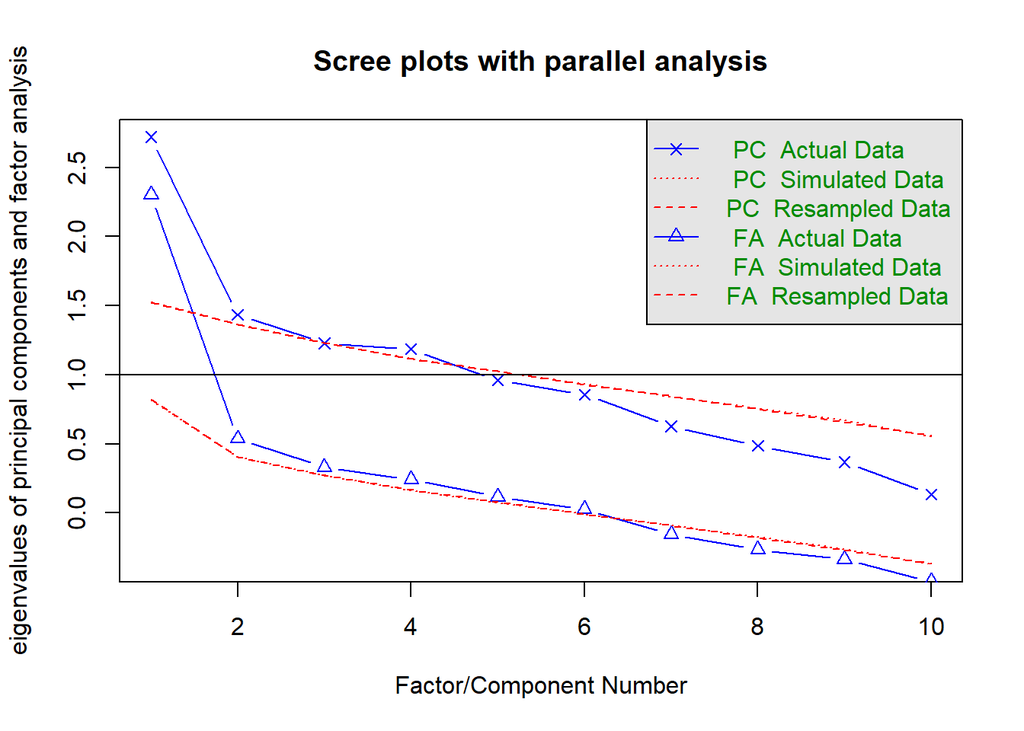

```
## Parallel analysis suggests that the number of factors =  2  and the number of components =  1
```

```r
#Parallel Analysis to determine the number of factors and components
fa.parallel(topsongs.df[-c(1,1:4)], fa="both", n.iter=150,
            main="Scree plots with parallel analysis")
```

Therefore the number of Factors = 2 and number of components = 1

## Factor Analysis

Factor Analysis is a statistical technique for identifying patterns in observed variables and explaining connections between them in terms of underlying, unobserved variables called as factors.Factor analysis assumes that the observed variables are influenced by a small number of unobserved variables, or factors, which are responsible for the observed correlations among the variables.  
These factors are extracted from the data using statistical methods, and the amount of variance each factor explains is called its eigenvalue.

we are performing factor analysis on our data frame *fa_topsongs* consisting of top songs data with their audio features. We are excluding the first four columns from the data frame as they contain non-numeric data.

We want to extract two factors and thus we have set *nfactors* to 2. We have rotate set to *varimax* because rotation simplifies the factor structure and makes it more interpretable to analyze. And the factoring method used is principal axis factoring

```r
#Factor Analysis
fa_topsongs <- data.frame(topsongs.df[-c(1,1:4)])
fa_topsongs <- fa(fa_topsongs, nfactors=2, rotate="varimax", fm="pa")
```

In factor analysis, loading is a measure of the relationship between the observed variables and the underlying factors. It represents the correlation between the variables and the factors.They are expressed as numbers ranging from -1 to 1, with higher absolute values indicating stronger relationships between the variables and the factors.If a variable has a high loading on a particular factor, it is likely that the variable is measuring the same underlying construct as the other variables that also load highly on that factor.

```r
#loadings of the observed variables represent the correlation between the variable and the factor.
fa_topsongs_loading <- (fa_topsongs$loadings)
fa_topsongs_loading
```

```
##
## Loadings:
##                  PA1    PA2
## beats.per.minute  0.310
## energy            0.962
## danceability      0.134  0.467
## loudness.dB       0.720
## liveness          0.119 -0.162
## valance           0.251  0.947
## length                  -0.158
## acousticness     -0.770
## speechiness
## popularity       -0.221
##
##                  PA1   PA2
## SS loadings    2.280 1.171
## Proportion Var 0.228 0.117
## Cumulative Var 0.228 0.345
```

We can see from above that Energy has a high loading on PA1, and Valance has a high loading on PA2

Adding the new columns PA1 and PA2 to our main data frame *topsongs.df*

```r
#adding the values of PA1 and PA2 to our main dataframe
fa_topsongs <- data.frame(fa_topsongs$scores)
topsongs.df <- cbind.data.frame(topsongs.df,fa_topsongs)
```

## Principal Component Analysis (PCA)

Principal Component Analysis is used to analyze and reduce the dimensionality of a large dataset.  
In PCA, a set of variables that are highly correlated with each other are transformed into a new set of uncorrelated variables, called principal components. These principal components are linear combinations of the original variables and are ranked in order of importance, with the first principal component capturing the largest amount of variation in the data, the second component capturing the second-largest amount of variation, and so on.

PCA involves finding the eigenvectors and eigenvalues of the covariance matrix of the original dataset. The eigenvectors represent the direction of maximum variance in the data and form the new set of uncorrelated variables (i.e., the principal components). The eigenvalues represent the amount of variance in the data that is explained by each principal component.

```r
#Principal Component Analysis
pca_topsongs <- data.frame(topsongs.df[-c(1,1:4)])
pca_topsongs <- principal(pca_topsongs[-c(11,12)], nfactors=1, score=TRUE)
```

Loadings refer to the values that indicate the strength of the relationship between the original variables and the principal components.

After performing PCA, you get a set of principal components that are a linear combination of the original variables. The loadings represent the weights of each variable in the linear combination of the principal component.

```r
pca_topsongs_loading <- (pca_topsongs$loadings)
pca_topsongs_loading
```

```
##
## Loadings:
##                  PC1
## beats.per.minute  0.416
## energy            0.889
## danceability      0.340
## loudness.dB       0.793
## liveness          0.109
## valance           0.467
## length
## acousticness     -0.828
## speechiness
## popularity       -0.304
##
##                  PC1
## SS loadings    2.723
## Proportion Var 0.272
```

```r
#adding the values of PC1 to our main dataframe
pca_topsongs <- data.frame(pca_topsongs$scores)
topsongs.df <- cbind.data.frame(topsongs.df,pca_topsongs)
```

## K-means Clustering

K-means clustering is a popular unsupervised machine learning technique used for partitioning a dataset into k distinct, non-overlapping clusters based on their attributes. It aims to minimize the sum of squared distances between data points and their assigned cluster centers. We perform k-means clustering using the kmeans() function, which takes as input a dataset and the desired number of clusters (k). The function then returns the cluster assignments and centroids.

We standardized the values of columns “PA1” and “PA2” using the scale() function and stored them in a new data frame called “df.norm”.This step is necessary for k-means clustering because the algorithm works based on the distance between points, and standardizing the values of the variables ensures that they are on the same scale and have equal influence in the distance calculation.

```r
#k-means clustering
df <- data.frame(topsongs.df[c("title","PA1", "PA2")])
df.norm <- sapply(df[,-1], scale)
row.names(df.norm) <- row.names(df)
```

We use the elbow method to calculate the desired number of clusters.  
The elbow method is a heuristic method used to determine the optimal number of clusters to use in k-means clustering.

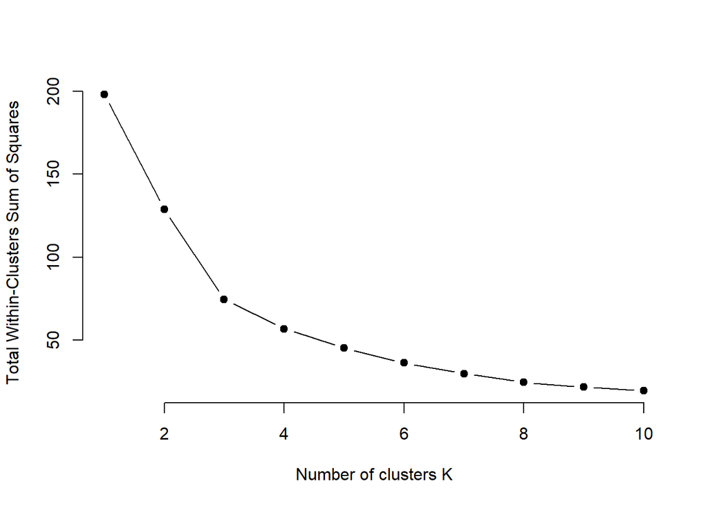

```r
#elbow method to determine number of clusters
wss <- sapply(1:10, function(k) {
  kmeans(df.norm, k, nstart = 50)$tot.withinss
})
plot(1:10, wss, type="b", pch = 19, frame = FALSE,
     xlab="Number of clusters K",
     ylab="Total Within-Clusters Sum of Squares")
```

```r
#The number of clusters = 4
```

We apply the k-means clustering to our normalized data. The output km contains information about the clusters such as cluster membership, cluster centers, and within-cluster sum of squares.  
We store the details of cluster membership in the dataframe km_list and add it to our main dataframe

```r
km <- kmeans(df.norm, 4)
# Adding the clusters to the original dataframe
km_list <- data.frame(km$cluster)
topsongs.df <- cbind.data.frame(topsongs.df,km_list)
```

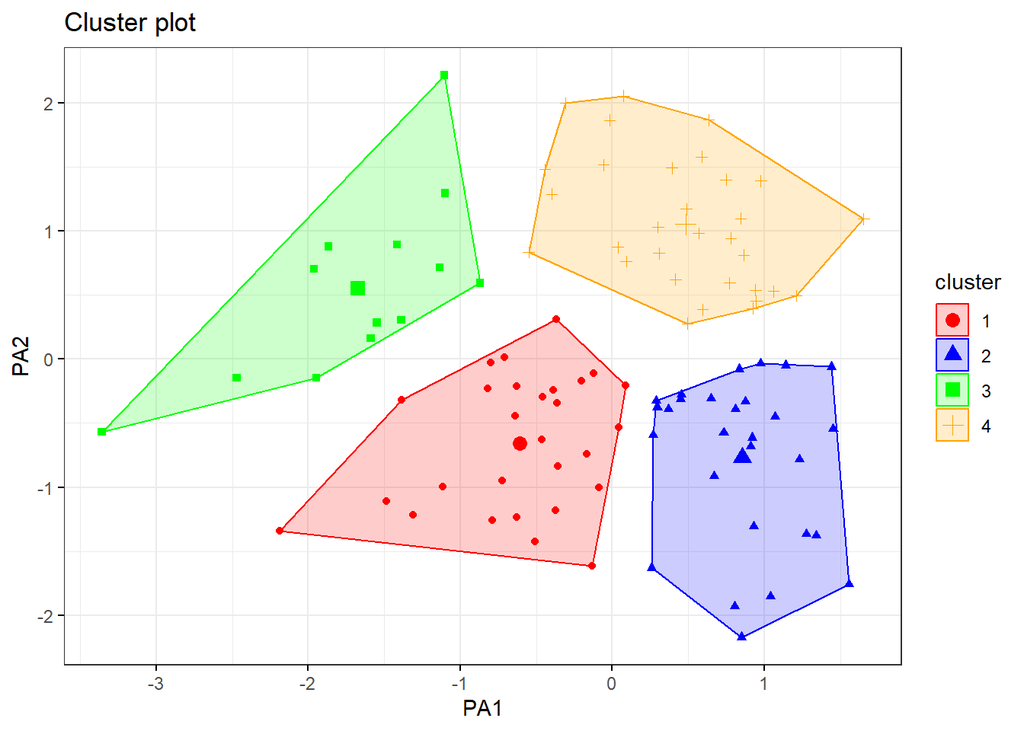

```r
#plotting cluster:
fviz_cluster(km, data = df.norm,
             palette = c("red", "blue", "green", "orange"),
             geom = "point",
             ellipse.type = "convex",
             ggtheme = theme_bw()
)
```

## Hierarchical Clustering

Hierarchical clustering is a popular method of clustering analysis that involves creating a hierarchy of clusters, often depicted as a dendrogram, through a series of successive partitions of a dataset. In hierarchical clustering, the data points are initially considered as individual clusters, and then pairs of clusters are merged in a way that minimizes a similarity or distance metric until all data points belong to the same cluster.

Hierarchical clustering can be visualized through a dendrogram, which displays the clusters and their merging sequence as a tree-like diagram. This makes it easier to interpret the results and to determine the optimal number of clusters. The choice of the distance metric used to compute the similarity between pairs of data points here is euclidean distance.

```r
#hierarchical clustering
df <- data.frame(topsongs.df[c("title","PA1", "PA2")])
df.norm <- sapply(df[,-1], scale)
row.names(df.norm) <- row.names(df)
d.norm <- dist(df.norm, method = "euclidean")
hc <- hclust(d.norm)
```

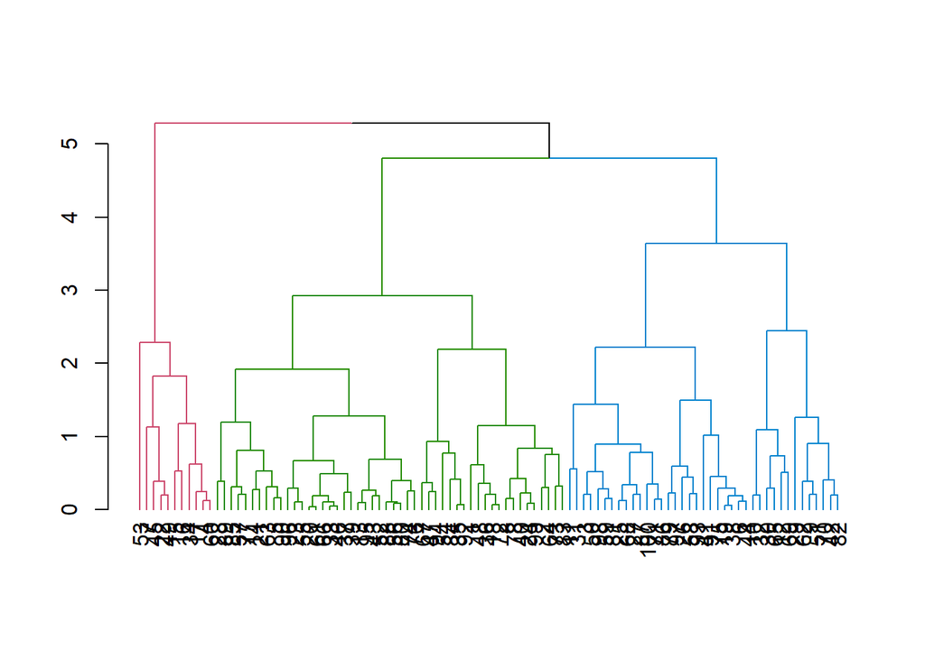

```r
#plotting the clusters
avg_dend_obj <- as.dendrogram(hc)
avg_col_dend <- color_branches(avg_dend_obj, h = 4)
plot(avg_col_dend)
```

```r
n_clusters=4
heir.cluster <- cutree(hc, k = n_clusters)# 4 is the number of clusters
```

```r
# Adding the clusters to the original dataframe
heir.cluster_list <- data.frame(heir.cluster)
topsongs.df <- cbind.data.frame(topsongs.df,heir.cluster_list)
```

We saw above that Energy and Valance had high loading on PA1 and PA2 respectively.  
We plot the scatter plot of energy vs valance grouped by our clusters form to draw further conclusions

```r
#plotting scatter plot energy vs valance (grouped by clusters formed by k-means)
#Code to select random points from the dataframe from each cluster to label them in the graph
random_points <- topsongs.df %>%
  mutate(cluster = km$cluster) %>%
  group_by(cluster) %>%
  sample_n(1)
random_points
```

```
## # A tibble: 4 × 20
## # Groups:   cluster [4]
##   title      artist top.g…¹  year beats…² energy dance…³ loudn…⁴ liven…⁵ valance
##   <chr>      <chr>  <chr>   <int>   <int>  <int>   <int>   <int>   <int>   <int>
## 1 Stay With… Sam S… dance …  2014      84     42      42      -6      11      18
## 2 Congratul… Post … dfw rap  2016     123     80      63      -4      25      49
## 3 Thinking … Ed Sh… pop      2014      79     45      78      -6      18      59
## 4 That's Wh… Bruno… dance …  2016     134     56      85      -5       9      86
## # … with 10 more variables: length <int>, acousticness <int>,
## #   speechiness <int>, popularity <int>, PA1 <dbl>, PA2 <dbl>, PC1 <dbl>,
## #   km.cluster <int>, heir.cluster <int>, cluster <int>, and abbreviated
## #   variable names ¹top.genre, ²beats.per.minute, ³danceability, ⁴loudness.dB,
## #   ⁵liveness
```

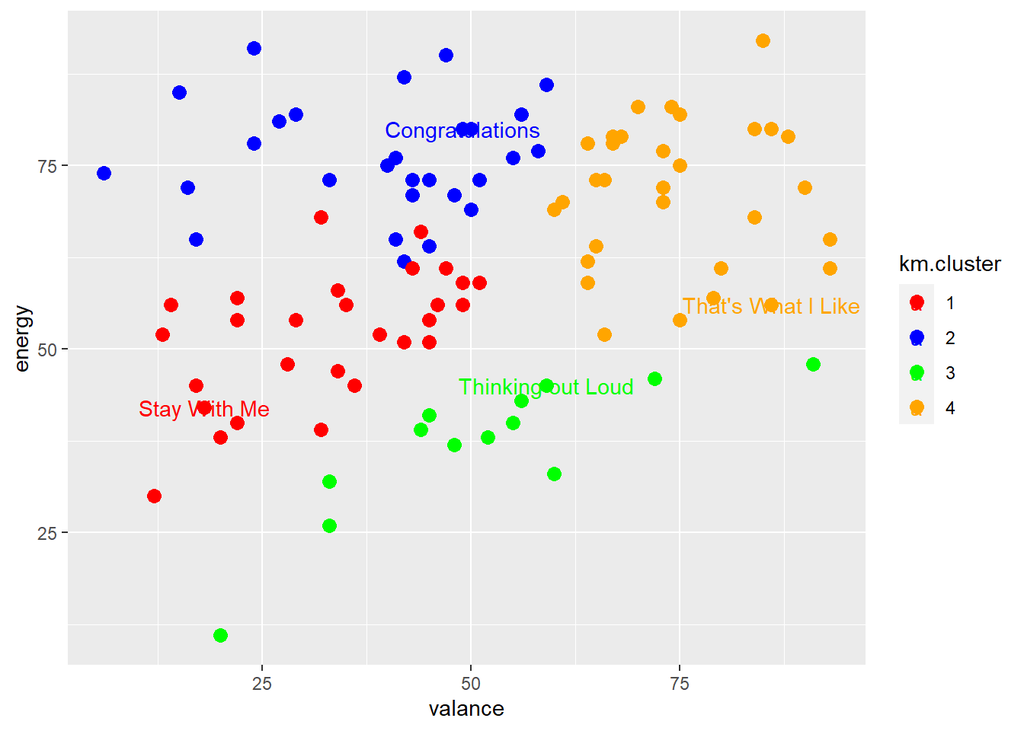

```r
topsongs.df %>% select(c("valance","energy","km.cluster"))%>%
  group_by(km.cluster) %>%
  ggplot(aes(x = valance, y = energy, color = factor(km.cluster))) +
  geom_point(size = 3) +
  scale_color_manual(values = c("red", "blue", "green", "orange")) +
  labs(color = "km.cluster") + geom_text(data = random_points, aes(x = valance, y = energy, label = random_points$title))
```

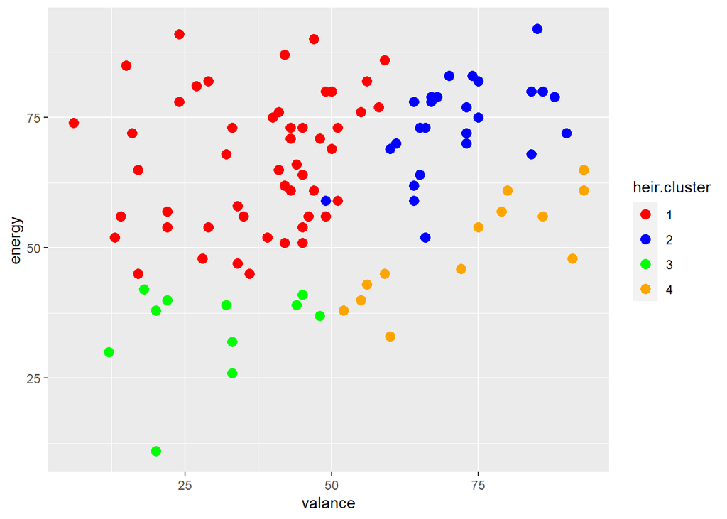

| Low Energy-Low Valance: Cluster 3 Songs tend to be slower, more introspective, and may have a sad or melancholic tone. | High Energy-Low Valance: Cluster 1 songs are characterized by their fast pace and upbeat rhythms, but often feature lyrics that deal with sad or emotional topics. |
| --- | --- |
| Low Energy-High Valance: Cluster 4 Songs tend to be more mellow and subdued in their sound, but still convey a positive, uplifting mood | High Energy-High Valance: Cluster 2 Songs are usually fast-paced, upbeat, and have a positive, joyful, or celebratory tone. |

[output not shown]

[output not shown]

[output not shown]

[output not shown]

```r
#plotting scatter plot energy vs valance (grouped by clusters formed by hierarchical clustering)
topsongs.df %>% select(c("valance","energy","heir.cluster"))%>%
  group_by(heir.cluster) %>%
  ggplot(aes(x = valance, y = energy, color = factor(heir.cluster))) +
  geom_point(size = 3) +
  scale_color_manual(values = c("red", "blue", "green", "orange")) +
  labs(color = "heir.cluster")
```

## Applications

- If a person likes a song in a particular cluster, chances are high they will like the songs around it . This can help with song recommendations
- If an artist knows which cluster their songs belongs to, they can expand their audience by targeting listeners that listen to other songs in the cluster frequently.